# Mapping in R

GEOG 693g

Amy Hessl

19 November, 2019

### Motivation

Creating a study area map is something nearly all geoscientists need to do. There are some straightforward methods in R that make it possible to integrate with R Markdown and other programmable outlets. Further, there is a burgeoning area of R development in spatial methods and objects that may be of interest to some. Here we learn a few simple mapping tools.

#### Packages to Install for This Lesson:

```r
library("ggplot2")
theme_set(theme_bw())
library("sf")
library("rnaturalearth")
library("rnaturalearthdata")
library("rgeos")
library("ggspatial")
library("maps")
library("lwgeom")
```

### Base Map: The World

First, let us start with creating a base map of the world using ggplot2. This base map will then be extended with different map elements, as well as change the scale to focus on an area of interest. The package `rnaturalearth` provides a map of countries of the entire world. Use `ne_countries` to pull country data and choose the scale (rnaturalearthhires is necessary for scale = “large”). The function can return `sp` classes (default) or directly `sf` classes, as defined in the argument class():

```r
world <- ne_countries(scale = "medium", returnclass = "sf")
class(world)
```

```
## [1] "sf"         "data.frame"
```

Magically, it can be plotted with ggplot2:

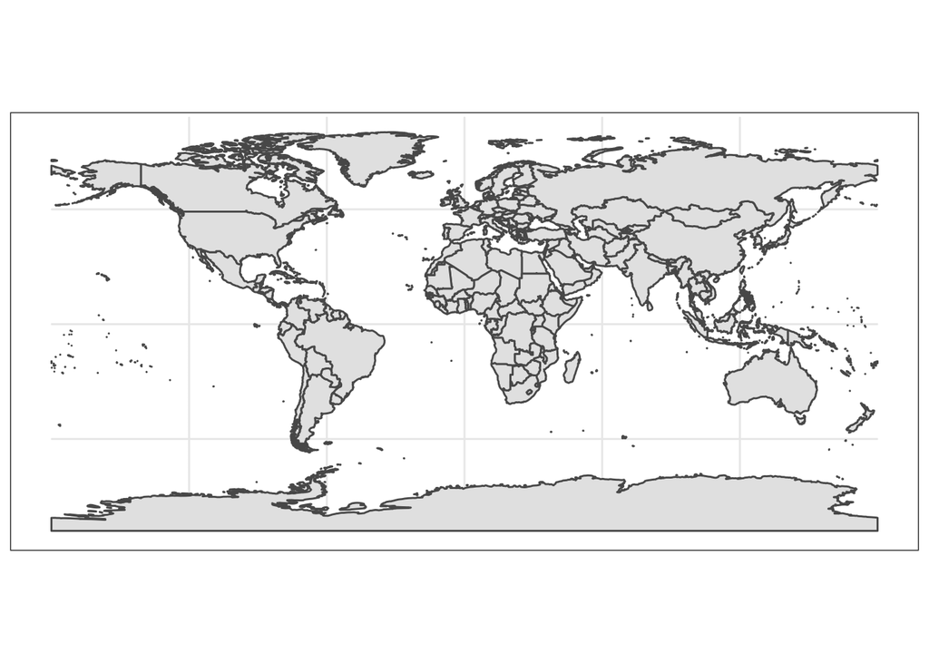

```r
ggplot(data = world) +
    geom_sf()
```

The line ends up with a + sign, which indicates that the call is not complete yet, and each subsequent line correspond to another layer or scale. In this case, we use the geom_sf(), which adds a geometry stored in a sf object. By default, all geometry functions use the main data defined in ggplot(), but we will see later how to provide additional data.

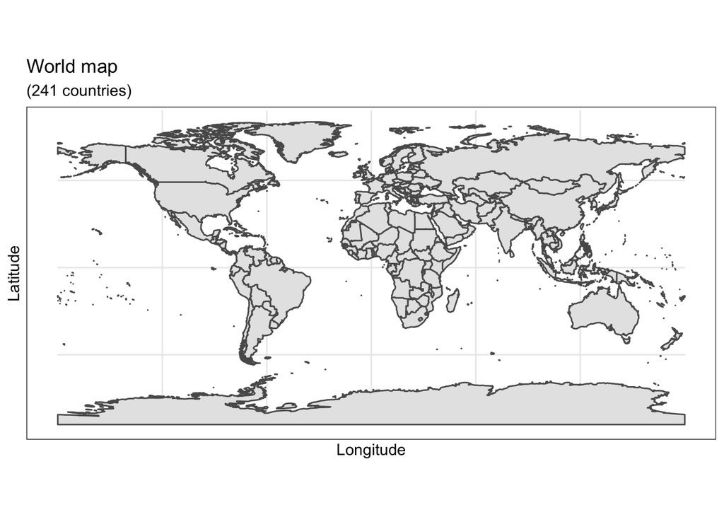

```r
ggplot(data = world) +
    geom_sf() +
    xlab("Longitude") + ylab("Latitude") +
    ggtitle("World map", subtitle = paste0("(", length(unique(world$name)), " countries)"))
```

#### Color and Fill

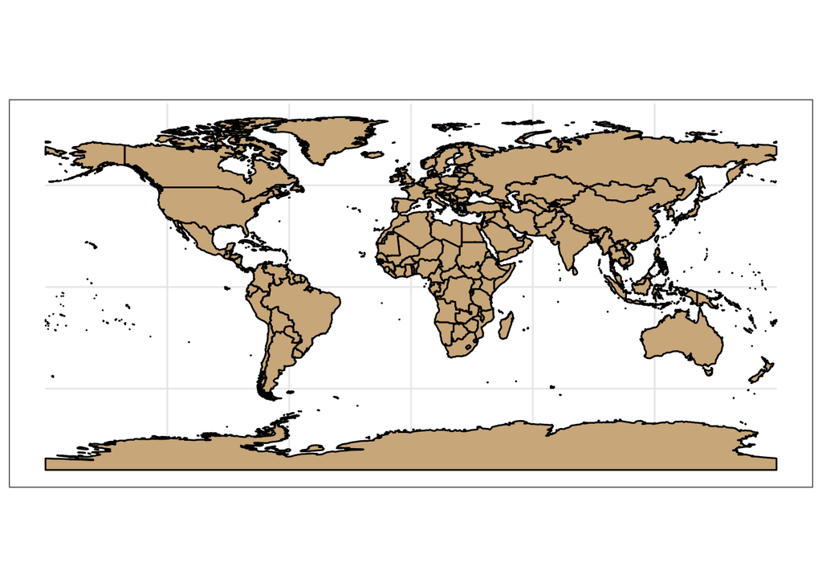

```r
ggplot(data = world) +
    geom_sf(color = "black", fill = "tan")
```

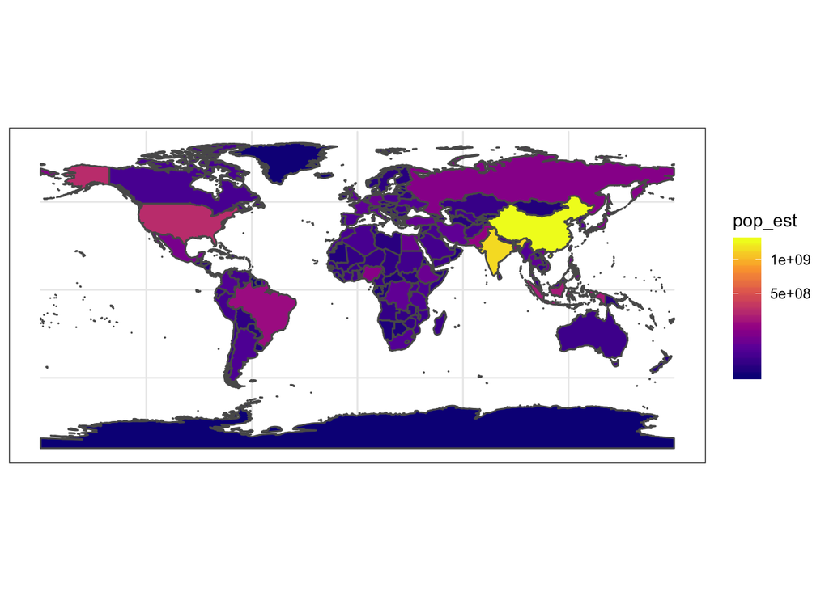

```r
ggplot(data = world) +
    geom_sf(aes(fill = pop_est)) +
    scale_fill_viridis_c(option = "plasma", trans = "sqrt")
```

#### Projection and extent (coord_sf)

The function coord_sf allows to define the coordinate system, which here includes both projection and extent of the map. By default, the map will use the coordinate system of the first layer that defines one (i.e. scanned in the order provided), or if none, fall back on WGS84 (latitude/longitude, the reference system used in GPS) - which is not really a projection!

Using the argument crs, it is possible to override this setting, and project on the fly to any projection. This can be achieved using any valid PROJ4 string (here, the European-centric ETRS89 Lambert Azimuthal Equal-Area projection):

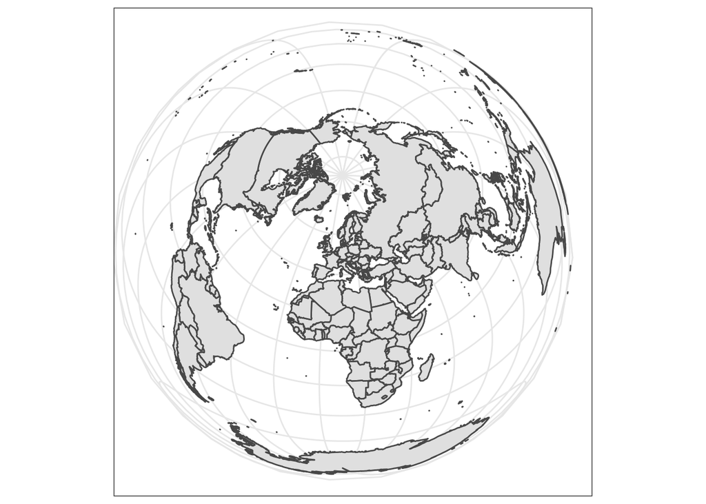

```r
ggplot(data = world) +
    geom_sf() +
    coord_sf(crs = "+proj=laea +lat_0=52 +lon_0=10 +x_0=4321000 +y_0=3210000 +ellps=GRS80 +units=m +no_defs ")
```

The extent of the map can also be set in coord_sf, in practice allowing to “zoom” in the area of interest, provided by limits on the x-axis (xlim), and on the y-axis (ylim). Note that the limits are automatically expanded by a fraction to ensure that data and axes don’t overlap; it can also be turned off to exactly match the limits provided with expand = FALSE:

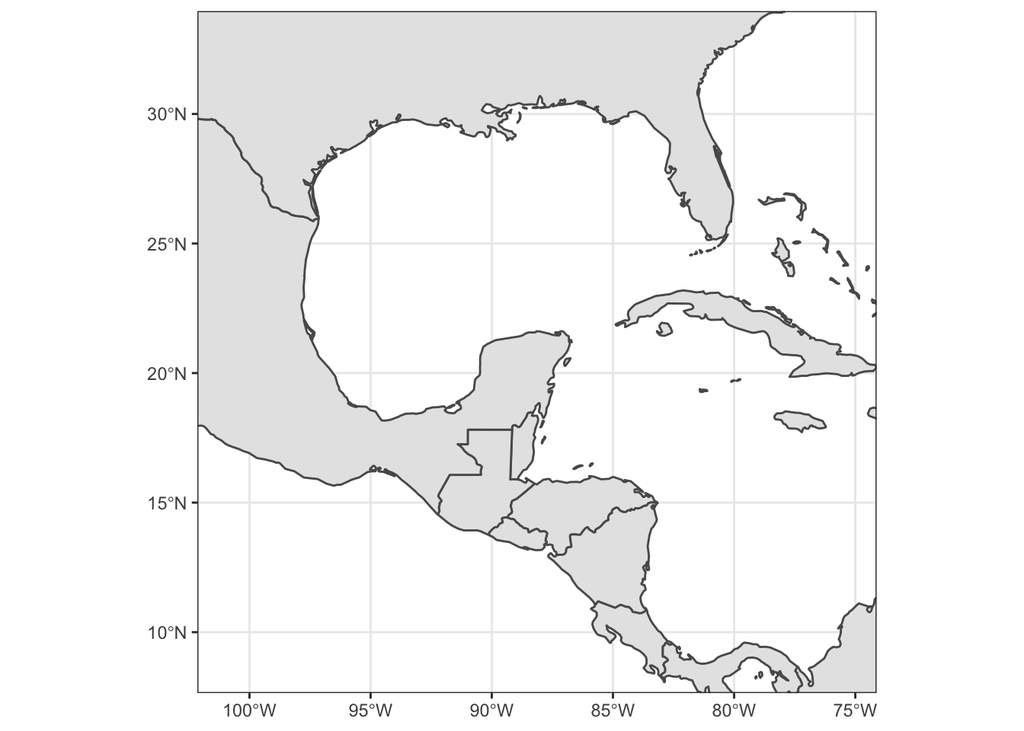

```r
ggplot(data = world) +
    geom_sf() +
    coord_sf(xlim = c(-102.15, -74.12), ylim = c(7.65, 33.97), expand = FALSE)
```

#### Scale bar and North arrow: package `ggspatial`

Several packages are available to create a scale bar on a map (e.g. prettymapr, vcd, ggsn, or legendMap). We introduce here the package ggspatial, which provides easy-to-use functions.

```
## Scale on map varies by more than 10%, scale bar may be inaccurate
```

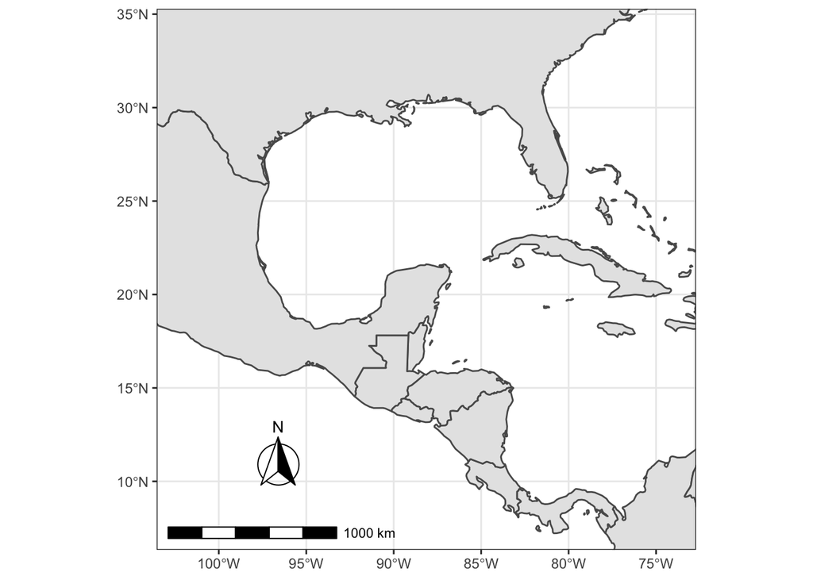

```r
ggplot(data = world) +
    geom_sf() +
    annotation_scale(location = "bl", width_hint = 0.5) +
    annotation_north_arrow(location = "bl", which_north = "true",
        pad_x = unit(0.75, "in"), pad_y = unit(0.5, "in"),
        style = north_arrow_fancy_orienteering) +
    coord_sf(xlim = c(-102.15, -74.12), ylim = c(7.65, 33.97))
```

Since that’s not really a projection, the scale bar can be highly inaccurate due to changing longitudinal distances.

#### Labels…are not easy

The world data set already contains country names and the coordinates of the centroid of each country (among more information). We can use this information to plot country names, using world as a regular data.frame in ggplot2. The function geom_text can be used to add a layer of text to a map using geographic coordinates. The function requires the data needed to enter the country names, which is the same data as the world map. Again, we have a very flexible control to adjust the text at will on many aspects:

For the text labels, we are defining the centroid of the counties with st_centroid, from the package sf. Then we combined the coordinates with the centroid, in the geometry of the spatial data frame. The package sf is necessary for the command st_centroid.  
* annotate function can be used to add a single character string at a specific location, as demonstrated here to add the Gulf of Mexico:

```r
library("sf")
world_points<- st_centroid(world)
world_points <- cbind(world, st_coordinates(st_centroid(world$geometry)))
```

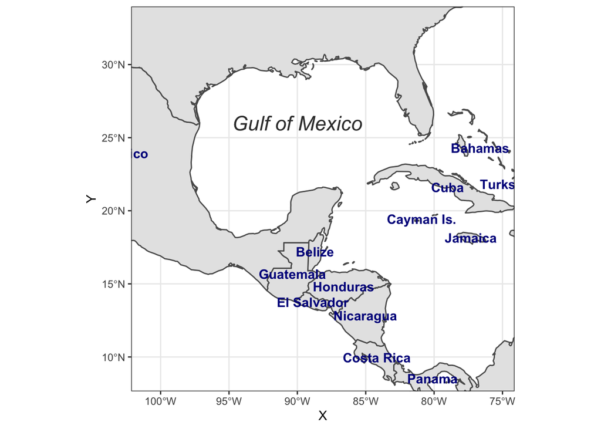

```r
ggplot(data = world) +
geom_sf() +
geom_text(data= world_points,aes(x=X, y=Y, label=name),
    color = "darkblue", fontface = "bold", check_overlap = FALSE) +
annotate(geom = "text", x = -90, y = 26, label = "Gulf of Mexico",
    fontface = "italic", color = "grey22", size = 6) +
coord_sf(xlim = c(-102.15, -74.12), ylim = c(7.65, 33.97), expand = FALSE)
```

#### Final map

Now to make the final touches, the theme of the map can be edited to make it more appealing. We suggested the use of theme_bw for a standard theme, but there are many other themes that can be selected from (see for instance ?ggtheme in ggplot2, or the package ggthemes which provide several useful themes). Moreover, specific theme elements can be tweaked to get to the final outcome:

Position of the legend: Although not used in this example, the argument legend.position allows to automatically place the legend at a specific location (e.g. “topright”, “bottomleft”, etc.); Grid lines (graticules) on the map: by using panel.grid.major and panel.grid.minor, grid lines can be adjusted. Here we set them to a gray color and dashed line type to clearly distinguish them from country borders lines; Map background: the argument panel.background can be used to color the background, which is the ocean essentially, with a light blue; Many more elements of a theme can be adjusted, which would be too long to cover here. We refer the reader to the documentation for the function theme.

```
## Scale on map varies by more than 10%, scale bar may be inaccurate
```

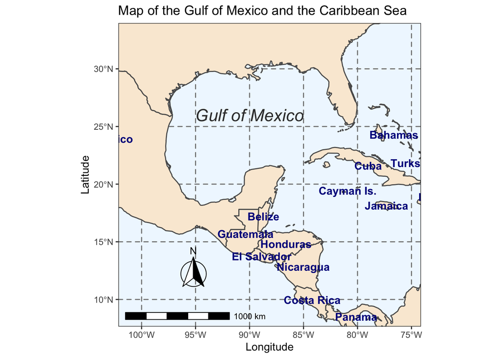

```r
ggplot(data = world) +
  geom_sf(fill= 'antiquewhite') +
  geom_text(data= world_points,aes(x=X, y=Y, label=name), color = 'darkblue', fontface = 'bold', check_overlap = FALSE) +
  annotate(geom = 'text', x = -90, y = 26, label = "Gulf of Mexico", fontface = 'italic', color = 'grey22', size = 6) +
  annotation_scale(location = 'bl', width_hint = 0.5) + annotation_north_arrow(location = 'bl', which_north = 'true', pad_x = unit(0.75, 'in'), pad_y = unit(0.5, 'in'), style = north_arrow_fancy_orienteering) +
  coord_sf(xlim = c(-102.15, -74.12), ylim = c(7.65, 33.97), expand = FALSE) +
  xlab('Longitude') +
  ylab('Latitude') +
  ggtitle('Map of the Gulf of Mexico and the Caribbean Sea') +
  theme(panel.grid.major = element_line(color = gray(.5), linetype = 'dashed', size = 0.5), panel.background = element_rect(fill = 'aliceblue'))
```

And if you want to save the map:  
`ggsave("map.pdf")`  
OR  
`ggsave("map_web.png", width = 6, height = 6, dpi = "screen")`

### Study Site Map

```r
(sites <- data.frame(site_id = c("Coopers", "Seneca"), longitude = c(-79.7878, -79.3762), latitude = c(39.6556, 38.8348)))
```

```
##   site_id longitude latitude
## 1 Coopers  -79.7878  39.6556
## 2  Seneca  -79.3762  38.8348
```

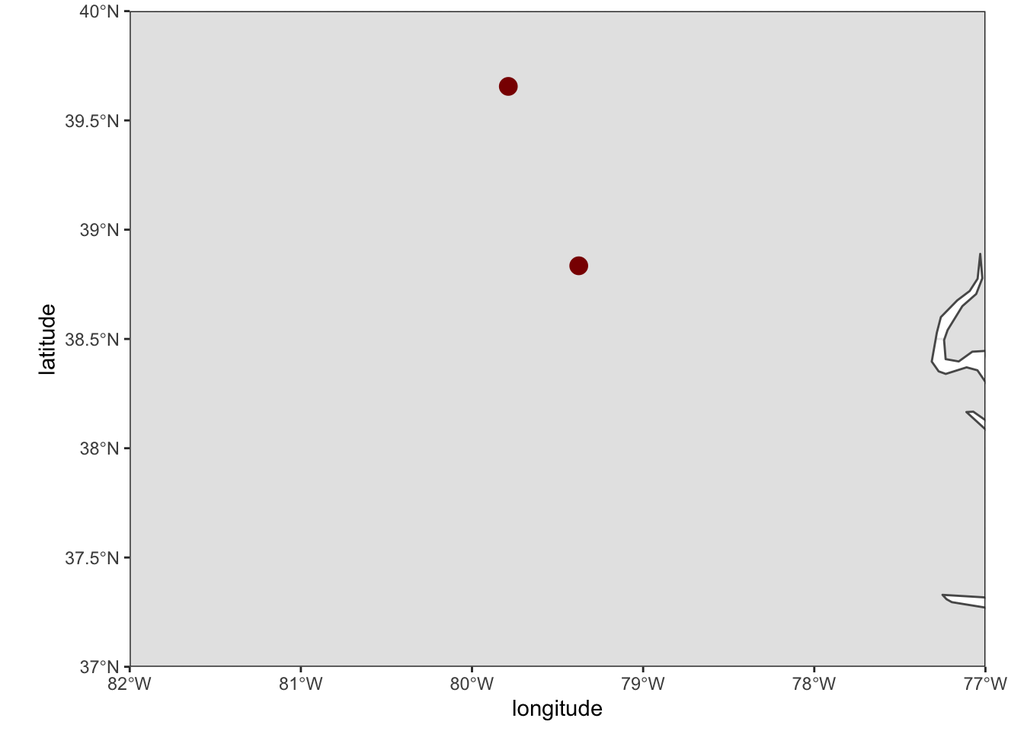

```r
ggplot(data = world) +
    geom_sf() +
    geom_point(data = sites, aes(x = longitude, y = latitude), size = 4,
        shape = 16, color = "darkred") +
    coord_sf(xlim = c(-82, -77), ylim = c(37, 40), expand = FALSE)
```

A better, more flexible alternative is to use the power of sf: Converting the data frame to a sf object allows to rely on sf to handle on the fly the coordinate system (both projection and extent), which can be very useful if the two objects (here world map, and sites) are not in the same projection. To achieve the same result, the projection (here WGS84, which is the CRS code #4326) has to be a priori defined in the sf object:

```r
(sites <- st_as_sf(sites, coords = c("longitude", "latitude"),
    crs = 4326, agr = "constant"))
```

```
## Simple feature collection with 2 features and 1 field
## Attribute-geometry relationship: 1 constant, 0 aggregate, 0 identity
## geometry type:  POINT
## dimension:      XY
## bbox:           xmin: -79.7878 ymin: 38.8348 xmax: -79.3762 ymax: 39.6556
## epsg (SRID):    4326
## proj4string:    +proj=longlat +datum=WGS84 +no_defs
##   site_id                 geometry
## 1 Coopers POINT (-79.7878 39.6556)
## 2  Seneca POINT (-79.3762 38.8348)
```

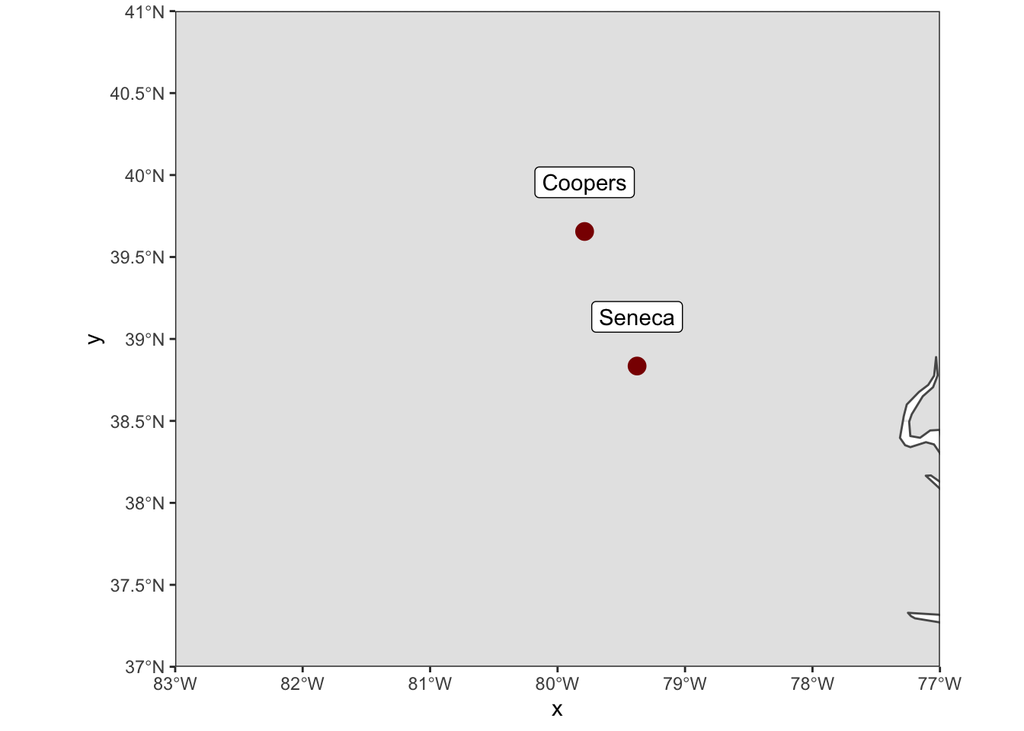

```r
ggplot(data = world) +
    geom_sf() +
    geom_sf(data = sites, size = 4, shape = 16, color = "darkred") +
    coord_sf(xlim = c(-81, -73), ylim = c(36, 41), expand = FALSE) +
    geom_sf_label(data=sites, aes(label = site_id), nudge_y = 0.3) +
    coord_sf(xlim = c(-83, -77), ylim = c(37, 41), expand = FALSE)
```

Note that coord_sf has to be called after all geom_sf calls, as to supersede any former input.

#### Add State Boundaries

```r
states <- st_as_sf(map("state", plot = FALSE, fill = TRUE))
head(states)
```

```
## Simple feature collection with 6 features and 1 field
## geometry type:  MULTIPOLYGON
## dimension:      XY
## bbox:           xmin: -124.3834 ymin: 30.24071 xmax: -71.78015 ymax: 42.04937
## epsg (SRID):    4326
## proj4string:    +proj=longlat +datum=WGS84 +no_defs
##                         geometry          ID
## 1 MULTIPOLYGON (((-87.46201 3...     alabama
## 2 MULTIPOLYGON (((-114.6374 3...     arizona
## 3 MULTIPOLYGON (((-94.05103 3...    arkansas
## 4 MULTIPOLYGON (((-120.006 42...  california
## 5 MULTIPOLYGON (((-102.0552 4...    colorado
## 6 MULTIPOLYGON (((-73.49902 4... connecticut
```

State names are part of this data, as the ID variable. A simple (but not necessarily optimal) way to add state name is to compute the centroid of each state polygon as the coordinates where to draw their names. Centroids are computed with the function `st_centroid`, their coordinates extracted with `st_coordinates`, both from the package sf, and attached to the state object:

```r
states <- cbind(states, st_coordinates(st_centroid(states)))
```

```
## Warning in st_centroid.sf(states): st_centroid assumes attributes are
## constant over geometries of x
```

```
## Warning in st_centroid.sfc(st_geometry(x), of_largest_polygon =
## of_largest_polygon): st_centroid does not give correct centroids for
## longitude/latitude data
```

```r
head(states)
```

```
## Simple feature collection with 6 features and 3 fields
## geometry type:  MULTIPOLYGON
## dimension:      XY
## bbox:           xmin: -124.3834 ymin: 30.24071 xmax: -71.78015 ymax: 42.04937
## epsg (SRID):    4326
## proj4string:    +proj=longlat +datum=WGS84 +no_defs
##            ID          X        Y                       geometry
## 1     alabama  -86.83042 32.80316 MULTIPOLYGON (((-87.46201 3...
## 2     arizona -111.66786 34.30060 MULTIPOLYGON (((-114.6374 3...
## 3    arkansas  -92.44013 34.90418 MULTIPOLYGON (((-94.05103 3...
## 4  california -119.60154 37.26901 MULTIPOLYGON (((-120.006 42...
## 5    colorado -105.55251 38.99797 MULTIPOLYGON (((-102.0552 4...
## 6 connecticut  -72.72598 41.62566 MULTIPOLYGON (((-73.49902 4...
```

Note the warning, which basically says that centroid coordinates using longitude/latitude data (i.e. WGS84) are not exact, which is perfectly fine for our drawing purposes. State names, which are not capitalized in the data from maps, can be changed to title case using the function `str_to_title` from the package stringr (part of tidyverse):

```r
library("stringr")
states$ID <- str_to_title(states$ID)
head(states)
```

```
## Simple feature collection with 6 features and 3 fields
## geometry type:  MULTIPOLYGON
## dimension:      XY
## bbox:           xmin: -124.3834 ymin: 30.24071 xmax: -71.78015 ymax: 42.04937
## epsg (SRID):    4326
## proj4string:    +proj=longlat +datum=WGS84 +no_defs
##            ID          X        Y                       geometry
## 1     Alabama  -86.83042 32.80316 MULTIPOLYGON (((-87.46201 3...
## 2     Arizona -111.66786 34.30060 MULTIPOLYGON (((-114.6374 3...
## 3    Arkansas  -92.44013 34.90418 MULTIPOLYGON (((-94.05103 3...
## 4  California -119.60154 37.26901 MULTIPOLYGON (((-120.006 42...
## 5    Colorado -105.55251 38.99797 MULTIPOLYGON (((-102.0552 4...
## 6 Connecticut  -72.72598 41.62566 MULTIPOLYGON (((-73.49902 4...
```

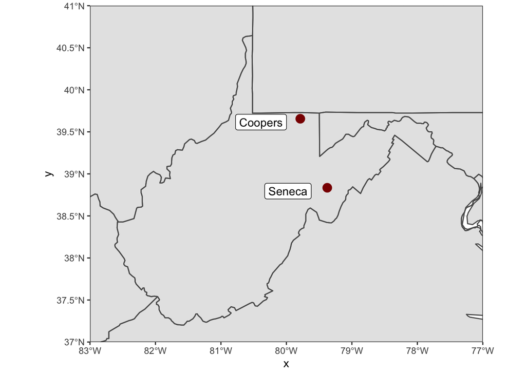

```r
ggplot(data = world) +
    geom_sf() +
    geom_sf(data = states, fill = NA) +
    geom_sf(data = sites, size = 4, shape = 16, color = "darkred") +
    coord_sf(xlim = c(-81, -73), ylim = c(36, 41), expand = FALSE) +
    geom_sf_label(data=sites, aes(label = site_id), nudge_x = -0.6, nudge_y = -.04) +
    coord_sf(xlim = c(-83, -77), ylim = c(37, 41), expand = FALSE)
```

#### Counties (polygon data)

County data are also available from the package maps, and can be retrieved with the same approach as for state data. This time, only counties from West Virginia are retained, and we compute their area using st_area from the package sf (depends on package lwgeom):

```r
counties <- st_as_sf(map("county", plot = FALSE, fill = TRUE))
counties <- subset(counties, grepl("west virginia", counties$ID))
counties$area <- as.numeric(st_area(counties))
head(counties)
```

```
## Simple feature collection with 6 features and 2 fields
## geometry type:  MULTIPOLYGON
## dimension:      XY
## bbox:           xmin: -82.49446 ymin: 37.76938 xmax: -77.81912 ymax: 40.41071
## epsg (SRID):    4326
## proj4string:    +proj=longlat +datum=WGS84 +no_defs
##                            geometry                     ID       area
## 2927 MULTIPOLYGON (((-79.80729 3...  west virginia,barbour  924542208
## 2928 MULTIPOLYGON (((-78.04258 3... west virginia,berkeley  834971361
## 2929 MULTIPOLYGON (((-81.45741 3...    west virginia,boone 1290567928
## 2930 MULTIPOLYGON (((-81.02197 3...  west virginia,braxton 1314958189
## 2931 MULTIPOLYGON (((-80.62662 4...   west virginia,brooke  252329877
## 2932 MULTIPOLYGON (((-82.25955 3...   west virginia,cabell  761343262
```

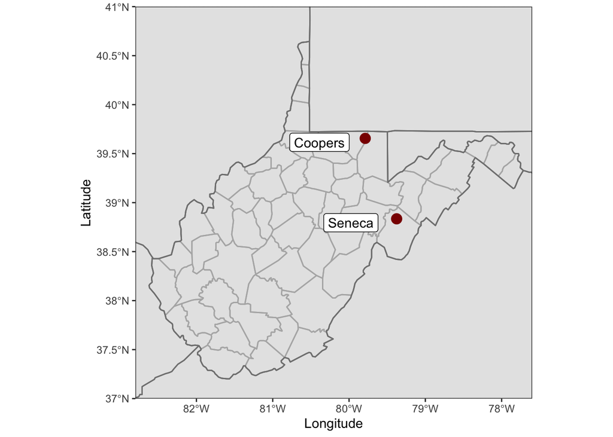

```r
study_area <- ggplot(data = world) +
    geom_sf() +
    geom_sf(data = counties, fill = NA, color = gray(.7)) +
    geom_sf(data = states, fill = NA, color = gray(.5)) +
    geom_sf(data = sites, size = 4, shape = 16, color = "darkred") +
    coord_sf(xlim = c(-81, -73), ylim = c(36, 41), expand = FALSE) +
    xlab('Longitude') +
    ylab('Latitude') +
    geom_sf_label(data=sites, aes(label = site_id), nudge_x = -0.6, nudge_y = -.04) +
    coord_sf(xlim = c(-82.8, -77.6), ylim = c(37, 41), expand = FALSE)
study_area
```

#### Key Points

- There are a growing suite of packages to support GIScience in R environment.
- Package sf is a good place to start.
- sf elements can be plotted wiht ggplot2.
- Elements are plotted as layers so their order is important.
- Map geometry is an important consideration, just as it is in any GIS. See [Overview of Coordinate Reference Systems (CRS)](https://www.nceas.ucsb.edu/~frazier/RSpatialGuides/OverviewCoordinateReferenceSystems.pdf)

#### **Acknowledgments**

*These pages were derived in part from: r-spatial.org*